# ST 558 Project 1 XML

Ariel Macari, Xiyou Zhou

# What is XML Data?

eXtensible Markup Language (XML) is a type of file used to store data. The stored data includes annotations to format the data but remins invisible to the user end. XML Data can be opened in a web browswer or any text editor. It is good use to store data for examples like a medical record.

[XML Data Example](https://www.ibm.com/support/knowledgecenter/en/SSLTBW_2.3.0/com.ibm.zos.v2r3.ib6p000/ib6p9c4m2.htm)

# R Packages

The following lists the packages that were used in this analysis

- XML - This package is a collection of functions
- Tidyverse - The tidyverse is a system of packages that helps in read, clean, and present data. The tidyverse includes the following packages
  - ggplot2 - functions for creating graphics
  - ddplyr - functions for data manipulation
  - tidyr - functions to tidy data
  - readr- functions to read in files
  - purr - functions to work with functions and vectors
  - tibble - a data frame with better options
  - stringr - functions to help working with strings
  - forcasts - functions to help with factors in R
- DT - This package allows R data ojbects to be displayed as tables on HTML pages.

# Data and Dataset

The data was found in [Dataset](https://catalog.data.gov/dataset/age-adjusted-death-rates-for-the-top-10-leading-causes-of-death-united-states-2013)

The data was read by the following: * First, a reference to the website as an object called `health`. * Next, the xmL referenced was parsed into a structure referencing the xml tree with `xmlParse`. * Last the data was brought in a dataframe with the function `xmlToDataFrame`. The function requests that a list of the xmL nodes to be processed be included. The nodes resided in “//response//row//(the attribute)” for each column.  
* The columns were combined and the columns were named * The number of deaths and aadr were converted to numeric. * The following shows the code that was used to import the data into RStudio and the data.

```r
health<-(file = "http://data.cdc.gov/api/views/bi63-dtpu/rows.xml?accessType=DOWNLOAD")
xmldoc <- xmlParse(health)

year <- xmlToDataFrame(nodes = getNodeSet(xmldoc, "//response//row//year"))
cause_name <- xmlToDataFrame(nodes = getNodeSet(xmldoc, "//response//row//cause_name"))
state <- xmlToDataFrame(nodes = getNodeSet(xmldoc, "//response//row//state"))
deaths <- xmlToDataFrame(nodes = getNodeSet(xmldoc, "//response//row//deaths"))
aadr <- xmlToDataFrame(nodes = getNodeSet(xmldoc, "//response//row//aadr"))

HealthData<-(cbind(year, cause_name, state, deaths, aadr))
colnames(HealthData)<- (c("year", "cause_name", "state", "deaths", "aadr"))


#convert to numeric!
HealthData$deaths<-as.numeric(as.character(HealthData$deaths))
HealthData$aadr<-as.numeric(as.character(HealthData$aadr))

# show the data!
(datatable(HealthData))
```

|  | year | cause_name | state | deaths | aadr |
| --- | --- | --- | --- | --- | --- |
| 1 | 2012 | Kidney disease | Vermont | 21 | 2.6 |
| 2 | 2016 | Kidney disease | Vermont | 30 | 3.7 |
| 3 | 2013 | Kidney disease | Vermont | 30 | 3.8 |
| 4 | 2000 | Suicide | District of Columbia | 23 | 3.8 |
| 5 | 2014 | Kidney disease | Arizona | 325 | 4.1 |
| 6 | 2009 | Suicide | District of Columbia | 29 | 4.4 |
| 7 | 2011 | Kidney disease | South Dakota | 49 | 4.5 |
| 8 | 2015 | Kidney disease | Vermont | 39 | 4.5 |
| 9 | 2014 | Kidney disease | Vermont | 37 | 4.5 |
| 10 | 2013 | Kidney disease | Arizona | 374 | 4.9 |

[output cut: 10286 more lines]

# Tables

- A contingency table showing that the dataset includes 18 years of the top 10 causes of death by state is shown below. The top 10 causes of death have remained the same throughout the years of 1999 - 2016. The following are the causes:
- All causes - The total number of deaths
- Alzheimer’s disease
- Cancer
- CLRD - Chronic Lower Respiratory Disease
- Diabetes
- Heart Disease
- Influenz and pneumonia
- kidney disease
- stroke
- suicide
- unintentional injury

```
##
##                        All causes Alzheimer's disease Cancer CLRD Diabetes
##   Alabama                      18                  18     18   18       18
##   Alaska                       18                  18     18   18       18
##   Arizona                      18                  18     18   18       18
##   Arkansas                     18                  18     18   18       18
##   California                   18                  18     18   18       18
##   Colorado                     18                  18     18   18       18
##   Connecticut                  18                  18     18   18       18
##   Delaware                     18                  18     18   18       18
##   District of Columbia         18                  18     18   18       18
##   Florida                      18                  18     18   18       18
##   Georgia                      18                  18     18   18       18
##   Hawaii                       18                  18     18   18       18
##   Idaho                        18                  18     18   18       18
##   Illinois                     18                  18     18   18       18
##   Indiana                      18                  18     18   18       18
##   Iowa                         18                  18     18   18       18
##   Kansas                       18                  18     18   18       18
##   Kentucky                     18                  18     18   18       18
##   Louisiana                    18                  18     18   18       18
##   Maine                        18                  18     18   18       18
##   Maryland                     18                  18     18   18       18
##   Massachusetts                18                  18     18   18       18
##   Michigan                     18                  18     18   18       18
##   Minnesota                    18                  18     18   18       18
##   Mississippi                  18                  18     18   18       18
##   Missouri                     18                  18     18   18       18
##   Montana                      18                  18     18   18       18
##   Nebraska                     18                  18     18   18       18
##   Nevada                       18                  18     18   18       18
##   New Hampshire                18                  18     18   18       18
##   New Jersey                   18                  18     18   18       18
##   New Mexico                   18                  18     18   18       18
##   New York                     18                  18     18   18       18
##   North Carolina               18                  18     18   18       18
##   North Dakota                 18                  18     18   18       18
##   Ohio                         18                  18     18   18       18
##   Oklahoma                     18                  18     18   18       18
##   Oregon                       18                  18     18   18       18
```

[output cut: 161 more lines]

```
##   Oregon                                   18
##   Pennsylvania                             18
##   Rhode Island                             18
##   South Carolina                           18
##   South Dakota                             18
##   Tennessee                                18
##   Texas                                    18
##   United States                            18
##   Utah                                     18
##   Vermont                                  18
##   Virginia                                 18
##   Washington                               18
##   West Virginia                            18
##   Wisconsin                                18
##   Wyoming                                  18
```

# New Variable

A new variable `Death_Percent` was created to calculate the % of deaths attributed by each causes per year at the National and State levels.

# Numeric Summary

The following shows the meand and standard deviation for % of deaths caussed by each cause and the aadr.

| cause_name | Mean_Deaths | stdev_deaths | mean_aadr | stdev_aadr |
| --- | --- | --- | --- | --- |
| Alzheimer’s disease | 3.0 | 0.63 | 23.5 | 3.44 |
| Cancer | 22.8 | 0.40 | 178.4 | 14.43 |
| CLRD | 5.4 | 0.26 | 42.6 | 1.48 |
| Diabetes | 2.9 | 0.08 | 23.0 | 1.93 |
| Heart disease | 25.8 | 2.40 | 203.5 | 34.82 |
| Influenza and pneumonia | 2.3 | 0.28 | 18.4 | 3.53 |
| Kidney disease | 1.8 | 0.15 | 14.1 | 0.83 |
| Stroke | 5.8 | 0.73 | 45.7 | 9.21 |
| Suicide | 1.4 | 0.15 | 11.7 | 1.00 |
| Unintentional injuries | 4.8 | 0.46 | 39.0 | 2.92 |

# Plot

A barplot for each cause by year is included below. The results show that Heart Disease and Cancer cause ~50% of the deaths in the US! The cause of deaths for heat disease is decreasing. However, the rate of deaths due to Althzheimers Disease is increasing !

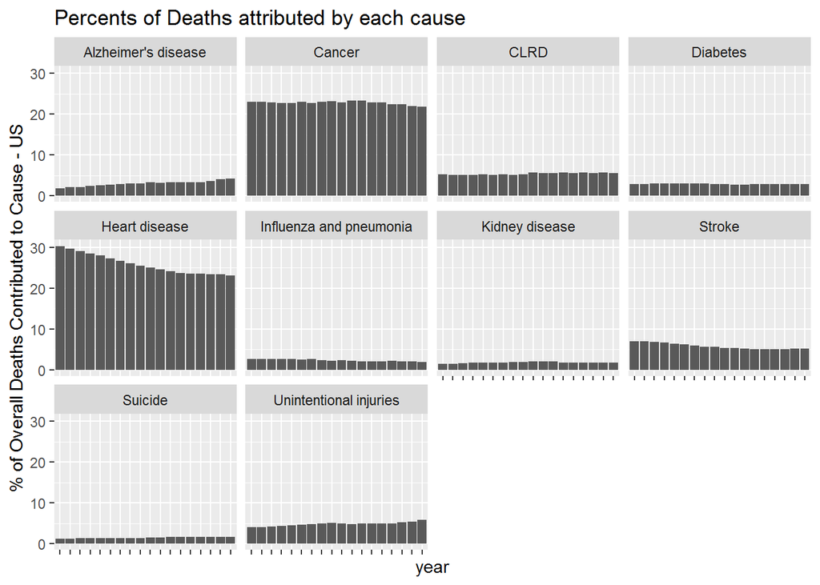

The % of deaths were attributed to the top ten causes by state. A boxplot was then plotted by cause. The results show the distribution for the causes of each death. The results show that Heart Disease and Cancer are the main causes of deaths in the US.

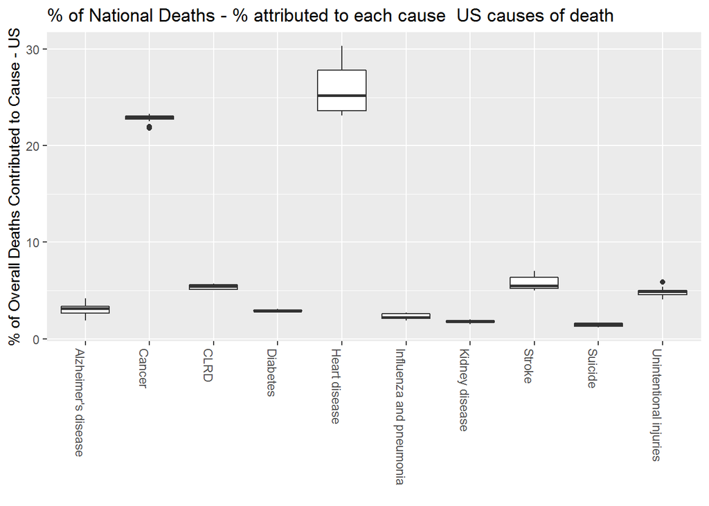

The plot below shows the number of deaths per year and the aadr. the total number has increased by about ~16% since 1999. The aadr rate has decreased from 880 to about 720.

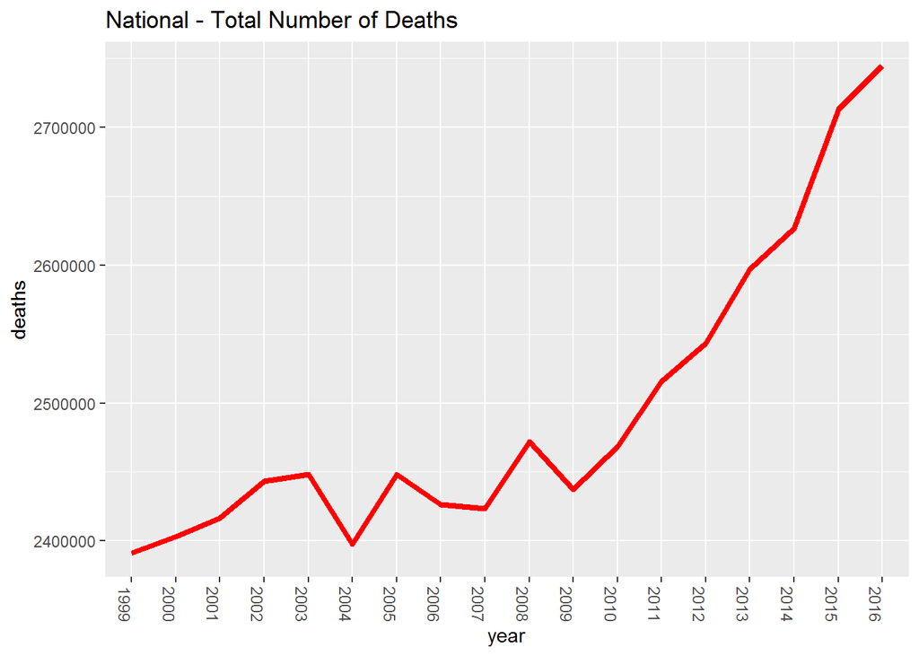

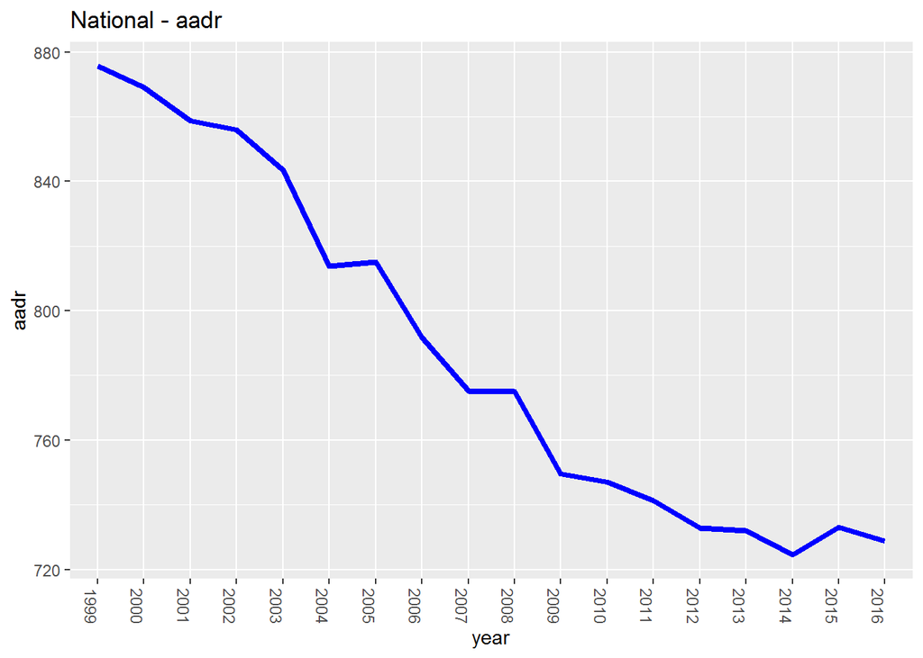